[figure not shown]

#### anglojęzyczna crowdfundingowa strona internetowa!

# Projekt Python - Kickstarter

## PaRaDoMa

#### Cel statystyczny: Analiza statystyczna, co wpływa na powodzenie lub niepowodzenia projektu?

#### Cel Python: Aplikacja pozwalająca określić prawdopodobieństwo powodzenia naszego projektu crowdfunding’owego oraz wskazująca, co należałoby poprawić, aby zwiększyć prawdopodobieństwo powodzenia.

#### Źródło danych: https://www.kaggle.com/kemical/kickstarter-projects?select=ks-projects-201801.csv

# Czego dotyczą dane?

Analiza zbiórek społecznościowych, tzw. crowdfunding, organizowanych na platformie internetowej Kickstarter w latach 2009 - 2018.

Dane pochodzą z 23 krajów (wśród nich nie było Polski) i zawierają informacje na temat poszczególnych projektów, tzn:

- ich wartości (wyrażonej w USD),
- liczby fundatorów,
- czasu trwania zbiórki,
- kategorii oraz podkategorii,
- info. czy dany projekt zakończył się sukcesem.

# Przygotowanie danych

# Ogólna analiza danych

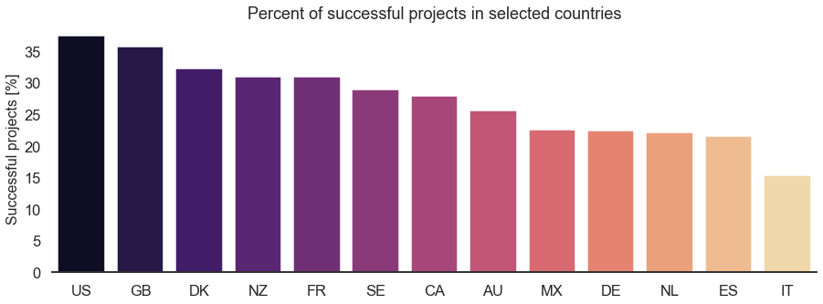

### Charakterystyka rozkładu liczby osób wspierających projekty

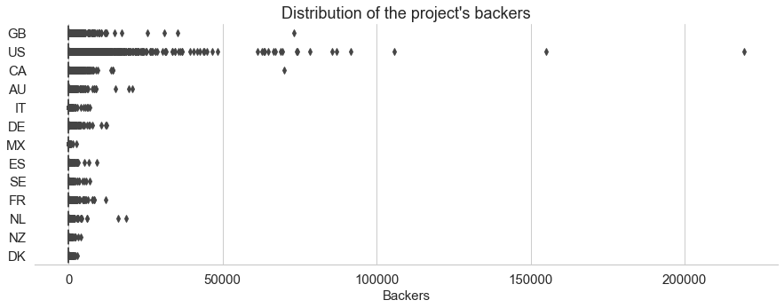

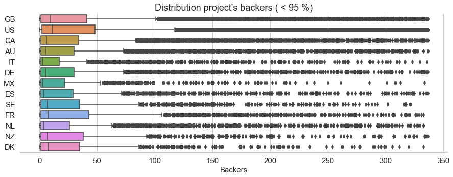

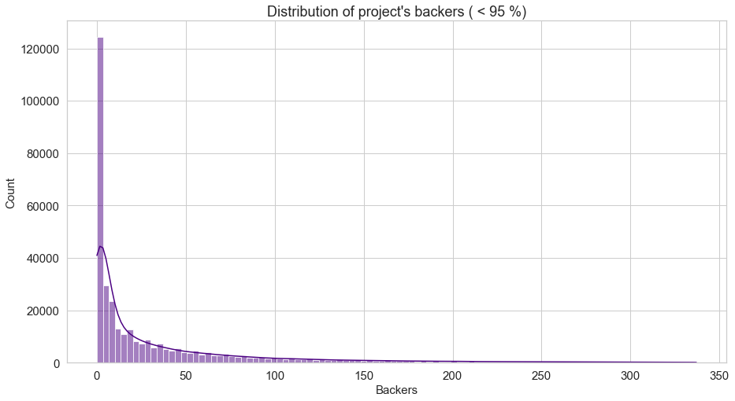

### Charakterystyka rozkładu liczby osób wspierających sfinansowane projekty

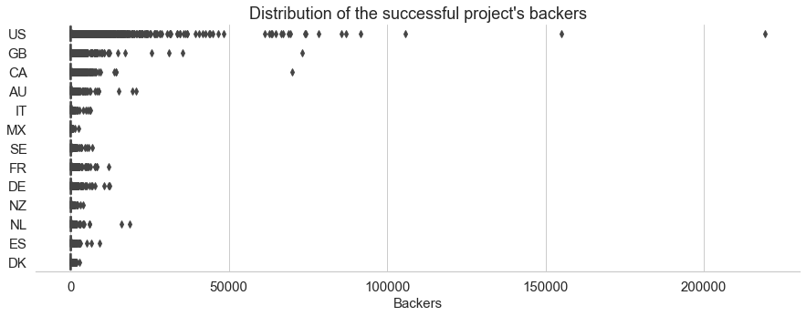

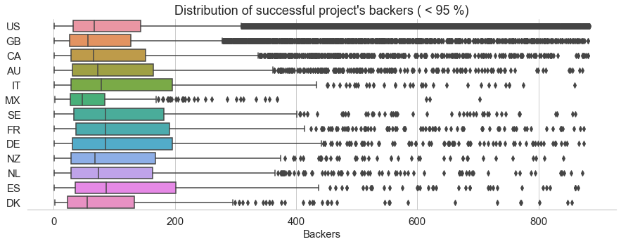

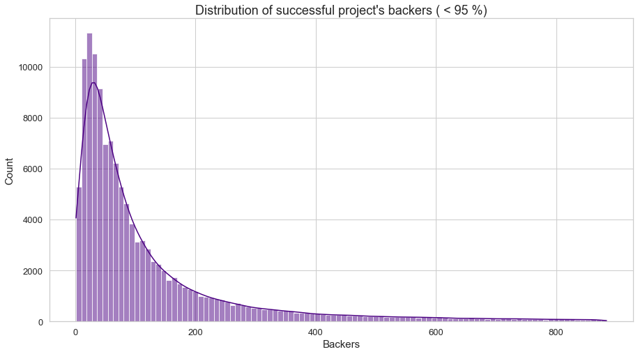

# Wyodrębnienie czynników mających wpływ na zakończenie projektu sukcesem

## 1. Miesiąc rozpoczęcia zbiórki

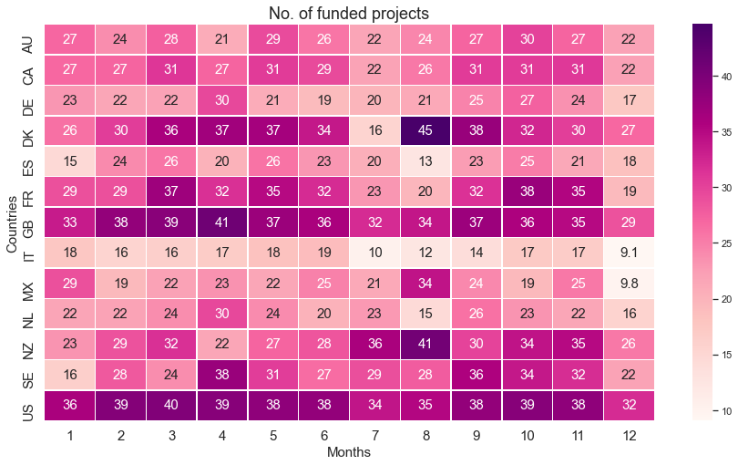

### W związku z tym, że nie ma wyraźnego trendu wskazującego na to, że w jakimś okresie szansa na uzyskanie finansowania projektu jest większa (zarówno najmniejsze jak i największe wartości są rozdystrybułowane dość przypadkowo), nie bierzemy tej zależności pod uwagę w budowaniu aplikacji.

## 2. Kategoria główna

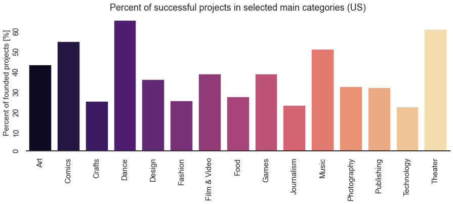

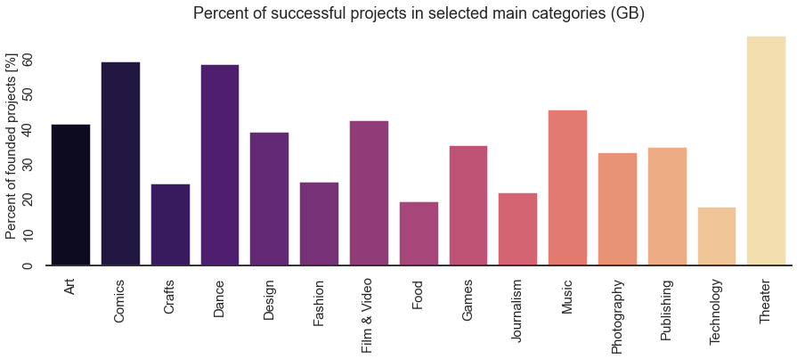

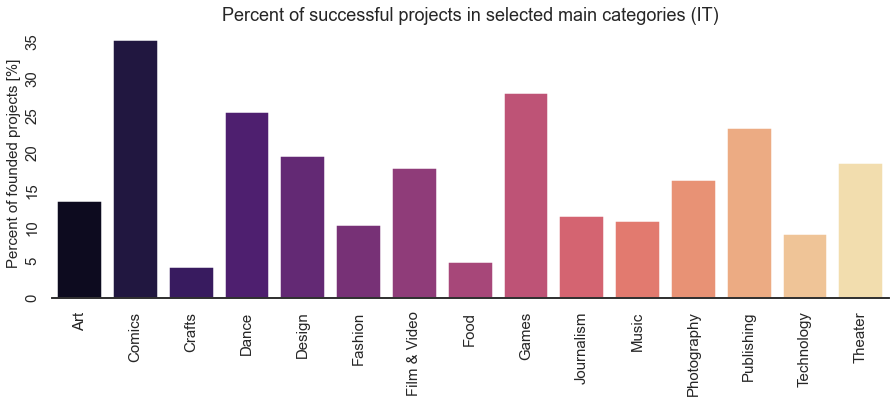

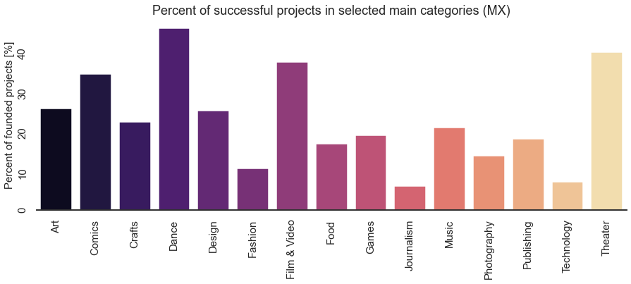

### We wszystkich państwach widać wyraźną zależność powodzenia projektu od tego w jakiej kategorii został złożony, więc kategoria będzie jednym z parametrów analizowanych w aplikacji.

## 3. Podkategoria

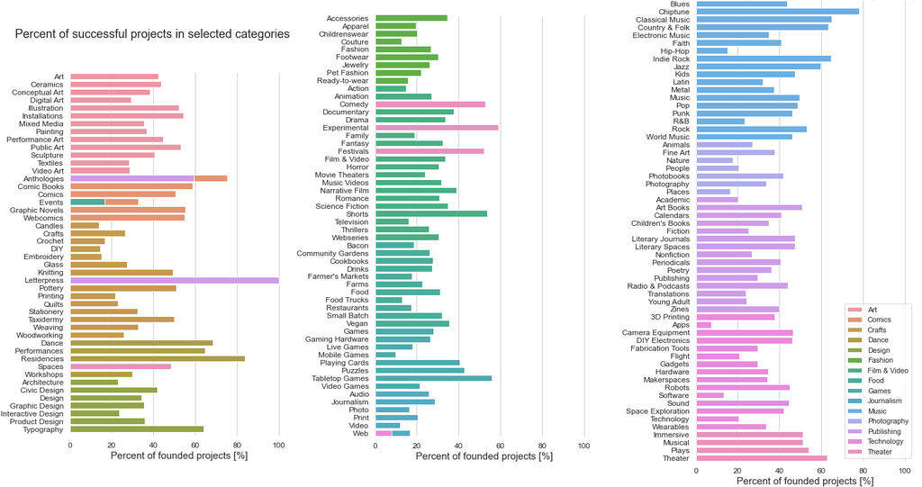

## 4. Czas trwania zbiórki

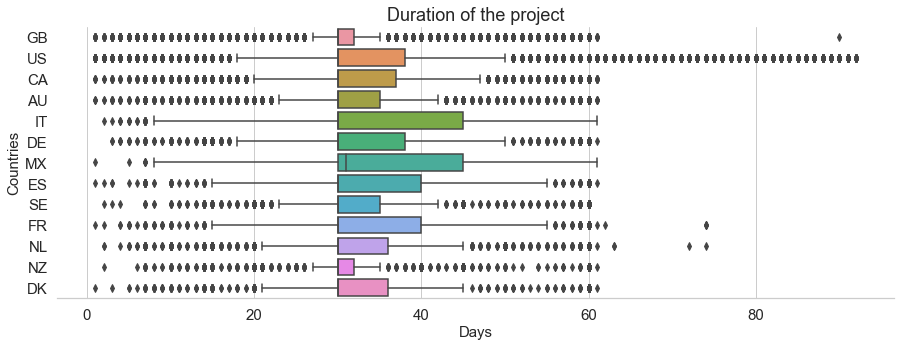

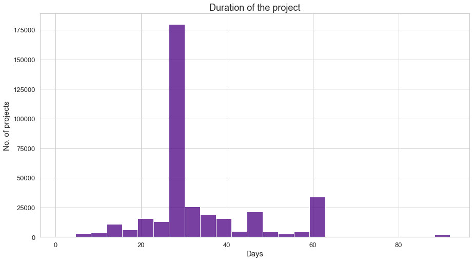

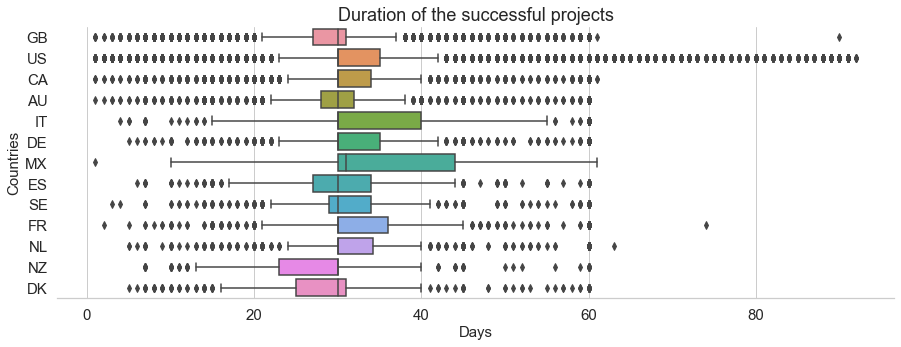

### Możliwe jest określenie przedziałów czasowych, które mogłyby zwiększyć prawdopodobieństwo zakończenia zbiórki sukcesem

## 5. Kwota zbiórki

### Charakterystyka rozkładu kwot zgłaszanych zbiórek

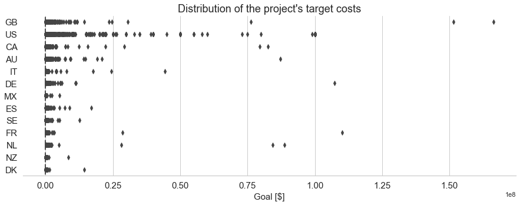

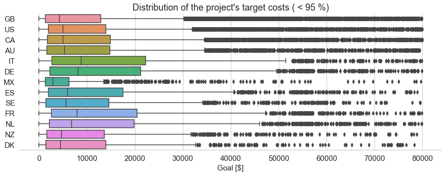

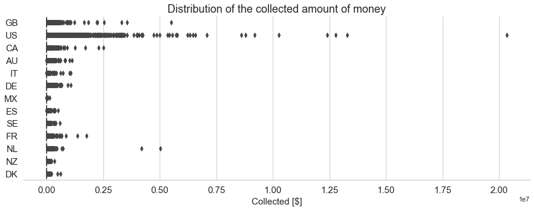

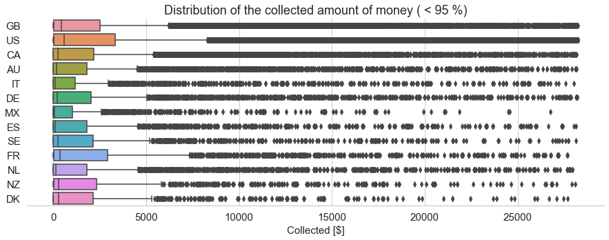

### Zadeklarowaną kwotę projektu należy uznać za czynnik mający wpływ na jego powodzenie